# Test System Theory - ODD student ID

```python
import platform
import sys
import os
import datetime
import hashlib

import numpy as np
import matplotlib.pyplot as plt
import scipy.signal
```

## Task 0

Fill variables with appropriate data and run code below:

- FirstName_and_LastName
- StudentID
- Group

```python
FirstName_and_LastName = "Rumiia_z_Bakhtiiarova"
StudentID              = 150207
Group                  = "odd"

#run

idd = "{} {} {}\nD={} P={}\nE={} V={}\n{} {}".format(FirstName_and_LastName, StudentID, Group, datetime.datetime.now(), os.getcwd(), sys.executable, platform.python_version(), platform.platform(), platform.machine())
print(idd)
print(hashlib.sha256(idd.encode()).hexdigest())
```

```
Rumiia_z_Bakhtiiarova 150207 odd
D=2022-02-01 12:11:27.952305 P=h:\SysTheorLab
E=H:\conda\python.exe V=3.9.5
Windows-10-10.0.19042-SP0 AMD64
b1fd64d66430646b7a9949bab6cfe0104e605b447525afc20cf5762ca47b1028
```

## Task 1 - Polynomials

Draw graphs:

- in the top-left part of the window, draw the graph of the function $f(x) = x^{13}-2x^7+x^2-3x+R$ for x in the interval $<-3; 5>$
- in the top-right half of the window, draw the graph of the function $g(x) = -x^2-3x-R$ for x in the interval $<-10; 12>$
- in the bottom half of the window, draw the graph of the function $h(x) = g(x)*f(x) - (R+9)x^9 + R$ for x in the interval $<-3; 8>$
- add titles, descriptions, grid, 12% margins

where R = last digit of your index number.

```
a=[ 1  0  0  0  0  0 -2  0  0  0  0 -3  9]
b=[-1 -3 -9]
c=[ -1  -3  -9   0   0   0  20   6  18   0   0   3   0   0 -82]
```

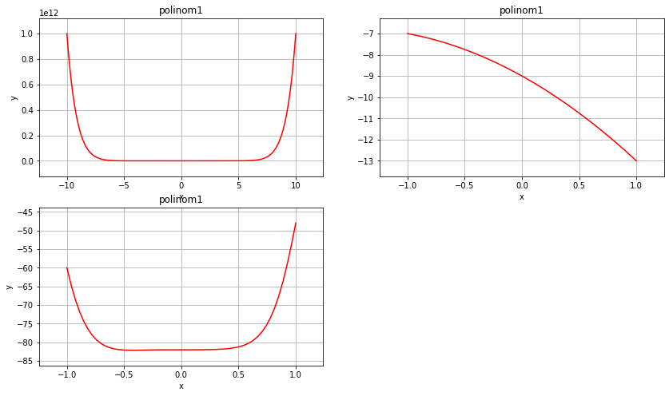

```python
#Task 1 - source code
import sympy
default_figsize=(14, 8)
def introduction_plot_polynomial():

    R = sympy.Symbol('R', real=True)
    R=9
    a = np.poly1d([ 1, 0, 0, 0, 0, 0, -2, 0, 0, 0, 0, -3, R])
    b = np.poly1d([  -1, -3, -R])
    c = np.polymul(a,b) -  np.poly1d([-(R+9), 0, 0, 0, 0, 0, 0, 0, 1])



    print ("a=" + str(a.coeffs))
    print ("b=" + str(b.coeffs))
    print ("c=" + str(c.coeffs))


    x1 = np.linspace(-10,10,200)
    x2 = np.linspace(-1,1,55)
    x3= np.linspace(-1,1,55)
    fig = plt.figure(1, figsize=default_figsize)

    plt.subplot(2,2,1)
    plt.plot(x1, a(x1),'r')
    plt.margins(0.12,0.12)
    plt.title("polinom1")
    plt.xlabel("x")
    plt.ylabel("y")
    plt.grid()

    fig = plt.figure(1, figsize=default_figsize)
    plt.subplot(2,2,2)
    plt.plot(x2, b(x2),'r')
    plt.margins(0.12,0.12)
    plt.title("polinom1")
    plt.xlabel("x")
    plt.ylabel("y")
    plt.grid()

    fig = plt.figure(1, figsize=default_figsize)
    plt.subplot(2,2,3)
    plt.plot(x3, c(x3),'r')
    plt.margins(0.12,0.12)
    plt.title("polinom1")
    plt.xlabel("x")
    plt.ylabel("y")
    plt.grid()






    return

introduction_plot_polynomial()
```

## Task 2 - Frequency response

Write code for a FUNCTION which draws a graph of amplitude (in the top half of the window) and phase (in the bottom half of the window) characteristics for a given frequency response. The function takes as arguments the coefficients of the numerator and denominator of the frequency response in the form of vectors B and A.  
The graphs must contain titles and descriptions of axes, 8 % margins.

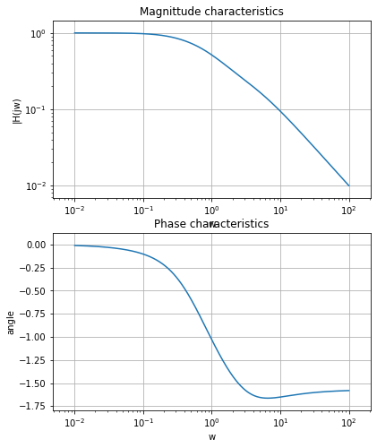

```python
#Task 2 - source code
def plotMandPCharacteristics(B, A):

 s = w*1j


 H = scipy.signal.freqs(B, A, w) [1]


 M = np.abs(H)
 P = np.angle(H)


 fig= plt.figure(1, figsize=default_figsize)
 plt.subplot(2,2,1)
 plt.loglog(w, M)
 plt.title("Magnittude characteristics")
 plt.xlabel("w")
 plt.ylabel("|H(jw)")
 plt.margins(0.08,0.08)
 plt.grid()

 fig= plt.figure(1, figsize=default_figsize)
 plt.subplot(2,2,3)
 plt.semilogx(w, P)
 plt.title("Phase characteristics")
 plt.xlabel("w")
 plt.ylabel("angle")
 plt.margins(0.08,0.08)
 plt.grid()


w = np.logspace(-2, 2, 1000)

    #plot plot plot
    #plot plot plot
    #plot plot plot


#test example
plotMandPCharacteristics([1, -3, 1], [1, -4, -2, 1])
```

## Task 3 - Complex exponential Fourier series

- Define the vector containing the samples of one period of the test signal from the graph (at least 200 samples).
- Based on the test function equation, find the signal decoposition into the complex exponential Fourier series (display equations for Fk).
- Display values of the first 2 complex exponential Fourier series coefficients (assume T=1).
- In a single graph, draw one period of the original signal (in RED) and the reconstructed signal (in GREEN) using the coefficients of Fk for |k| < (3+R),

  where R = the last digit of the index number.

TIP: Signal reconstruction from limited number of harmonics may be purely NUMERICAL solution (sum/difference of several signals/functions).  
DO NOT USE `ipywidgets`!!

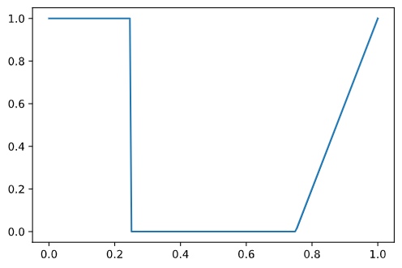

$\displaystyle 0.375$

$\displaystyle - \frac{0.5 i}{\pi k} + \frac{0.5 i e^{- 0.5 i \pi k}}{\pi k} + \frac{0.5 \left(i \pi k + 2\right)}{\pi^{2} k^{2}} - \frac{1.0 e^{- 1.5 i \pi k}}{\pi^{2} k^{2}}$

$\displaystyle \frac{0.5 i e^{- 0.5 i \pi k}}{\pi k} + \frac{1.0}{\pi^{2} k^{2}} - \frac{1.0 e^{- 1.5 i \pi k}}{\pi^{2} k^{2}}$

```
[ 3.75000000e-01+0.j          2.60476127e-01-0.10132118j
  5.06605918e-02-0.07957747j -4.17937384e-02+0.01125791j
 -9.54097912e-18+0.03978874j  3.58838360e-02-0.00405285j
  5.62895465e-03-0.02652582j -2.06686412e-02+0.00206778j
 -9.75781955e-18+0.01989437j]
```

```
array([ 3.75000000e-01+0.j        ,  2.60476127e-01-0.10132118j,
        5.06605918e-02-0.07957747j, -4.17937384e-02+0.01125791j,
       -9.54097912e-18+0.03978874j,  3.58838360e-02-0.00405285j,
        5.62895465e-03-0.02652582j, -2.06686412e-02+0.00206778j,
       -9.75781955e-18+0.01989437j])
```

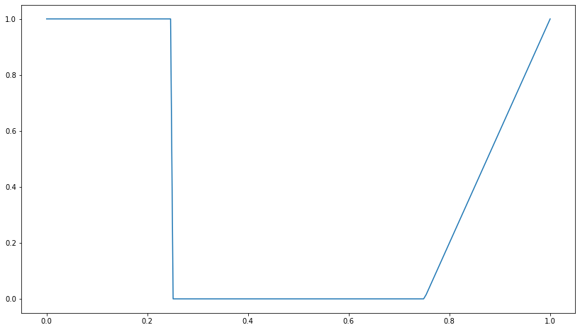

```python
#Task 3 - source code


#test function equation

#derive and display formulas for Fk

#derive and display values of the first 2 Fk

#draw original signal and the reconstructed one (reconstructed from limited number of harmonics)

t = sympy.Symbol('t', real = 'True', nonzero = 'True')
T = 1
fD = sympy.Piecewise((1, (t<=T/4)), (0, (t>=T/4) & (t<=3*T/4)), ((4*t/T-3), (t>3*T/4)))
                    #((1, t<= T/4),(0, t>=T/4, t<=3*T/4), (4*t/T-3, t>3*T/4))

#select one function
currFun = fD

#plot the selected function
NumberOfSamples = 200
Functor = sympy.lambdify(t, currFun, 'numpy')
Time = np.linspace(0, T, NumberOfSamples)
Samples = Functor(Time)
fig= plt.figure(1, figsize=default_figsize)
plt.plot(Time, Samples,  label = 'linear')




k = sympy.Symbol('k', real = 'True', nonzero=True, positive=True, integer=True)

def determineFourierCoefficients(Function, RangeBeg, RangeEnd):
    #declare kernel
    kernel = sympy.exp((-sympy.I * 2 * k * sympy.pi * t)/(T))
    #determine F0
    F0 = (1/T) * sympy.integrate(Function, (t, RangeBeg, RangeEnd))
    display(F0)
    #determine Fk
    Fk = (1/T) * sympy.integrate(Function * kernel, (t, RangeBeg, RangeEnd))
    display(Fk)
    display(Fk.simplify())
    return F0, Fk

F0, Fk = determineFourierCoefficients(currFun, 0, T)


coeffF0 = np.array(F0, dtype=np.cdouble)

fff = sympy.lambdify(k, Fk, 'numpy')
kkk = (np.arange(1,(3+R)))
coeffFk = fff(kkk)

#coeffFk = sympy.lambdify(k,Fk, 'numpy')(1,9)
coeff = np.append(coeffF0, coeffFk)

print(coeff)

display(coeff)
```

## Task 4 - Minimum-phase system

Check if the system H(s) is a minimum-phase system? $$ H(s)={{s^6+3.9s^5+6.01s^4+4.689s^3+1.963s^2+0.42s+0.036} \over {s^2-0.5s-0.5}} $$
Implement appropriate code and give a clear answer.

```python
#Task 4

W = np.logspace(-2, 2, 2)
B = np.poly1d([1, -0.5, 0.5])
A = np.poly1d([1, 3.9, 6.01, 4.689, 1.963, 0.42, 0.036])
s = W*1j
H = B(s)/A(s) # or  H = np.polyval(B,s)/np.polyval(A,s) the same of the beginning equation
M = np.abs(H)
P = np.angle(H)

print(np.roots(B))
print(np.roots(A))
print(M)
print(P)
```

```
[0.25+0.66143783j 0.25-0.66143783j]
[-1.2+0.00000000e+00j -1. +0.00000000e+00j -0.5+1.08544283e-07j
 -0.5-1.08544283e-07j -0.4+0.00000000e+00j -0.3+0.00000000e+00j]
[1.38680394e+01 9.99803027e-09]
[-0.12664493  0.04399919]
```

## Task 5

Write code for a FUNCTION which draws zeros (denoted by 'o') and poles (denoted by 'x') for a given frequency response on a single graph. The function takes as arguments the numerator and denominator of the frequency response in the form of vectors B and A. The graph must contain a title and descriptions of the axes.

```
[1.+6.68896751e-09j 1.-6.68896751e-09j]
[-5.57075056+0.j          0.28537528+0.31316126j  0.28537528-0.31316126j]
```

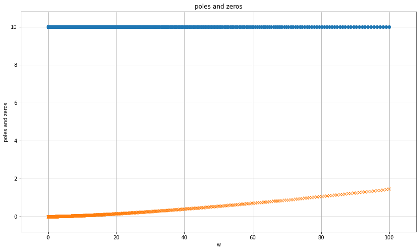

```python
#Task 5 - source code
def plotPolesAndZeros(B, A):
    w = np.logspace(-2, 2, 1000)
    poles = np.roots(B)
    y_poles = np.logspace(1+6.68896751e-09j, 1-6.68896751e-09j, 1000)
    y_zeros = np.logspace(-5.57075056,        0.28537528+0.31316126j ,1000)
    zeros = np.roots(A)
    print(poles)
    print(zeros)
    fig = plt.figure(1, figsize=default_figsize)
    plt.plot(w, y_poles, 'o', w, y_zeros, 'x')
    plt.title("poles and zeros")
    plt.xlabel("w")
    plt.ylabel("poles and zeros")
    plt.margins(0.08,0.08)
    plt.grid()
    #plot plot plot
    #plot plot plot
    #plot plot plot


#test example
plotPolesAndZeros([1, -2, 1], [1, 5, -3, 1])
```

## Task 6

Check if the system with frequency response H(s) is stable? $$ H(s)={{s^2+4} \over {polynomial, with, coefficients, equal, to, digits, of, index, number}} $$

If your student ID = 123456, then the transmittance is of the form: $$ H(s)={{s^2+4} \over {s^5+2s^4+3s^3+4s^2+5s+6}} $$ Implement appropriate code and give a clear answer.

```python
#Task 6 - source code

W = np.logspace(-2, 2, 2)
B = np.poly1d([1, 4])
A = np.poly1d([1, 2,3,4,5,6])
s = W*1j
H = B(s)/A(s) # or  H = np.polyval(B,s)/np.polyval(A,s) the same of the beginning equation
M = np.abs(H)
P = np.angle(H)

print(np.roots(B))
print(np.roots(A))
print(M)
print(P)
```

```
[-4.]
[ 0.55168546+1.25334886j  0.55168546-1.25334886j -1.49179799+0.j
 -0.80578647+1.22290471j -0.80578647-1.22290471j]
[6.66690046e-01 1.00089976e-08]
[-0.0058332  -0.01997935]
```

## Task 7

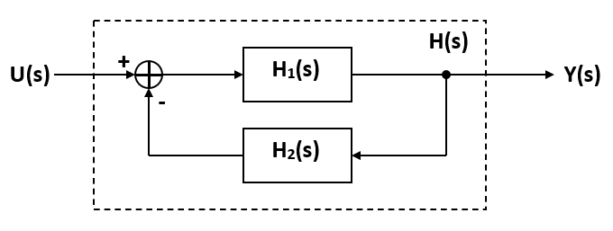

The frequency response of a closed-loop feedback system is: $$ H(s) = {{H_1(s)} \over {1 + H_1(s) \cdot H_2(s)}} $$ where $H_1(s)$ is the frequency response of the system and $H_2(s)$ is the frequency response in the feedback loop.

For:  
$H_1(s) = {{1} \over {s - 3.5}}$  
$H_2(s) = k$ (where $k$ is simply the k-times gain in the feedback loop, should be POSITIVE)

Check:

- is the system $H_1(s)$ stable?
- if it is NOT, is there a value of $k$ for which the closed-loop feedback system $H(s)$ becomes stable? Give range of $k$.

For the calculations use `sympy`, `sympy.solve`.

```python
#Task 7 - source code
```

[output not shown]

## Additional task - trigonometric Fourier series

- Use signal from Task 3.
- Based on the function equation, find the signal decoposition into the trigonometric Fourier series (display equations for a0, ak, bk).
- Display values of the first 3 coefficients (assume T=1) - just display them.
- In a single graph, draw one period of the original signal (in RED) and the reconstructed signal (in GREEN) using the coefficients a0, ak and bk for k < (3+R),

  where R = the last digit of the index number.

TIP: Signal reconstruction from limited number of harmonics may be purely NUMERICAL solution (sum/difference of several signals/functions).  
DO NOT USE `ipywidgets`!!

```python
#Additional task - source code

import math
#declare symbolic variable k
k = sympy.Symbol('k', real = 'True', nonzero=True, positive=True, integer=True)

def determineFourierCoefficients(Function):
    #declare kernel
    kernel1 = sympy.exp(-sympy.I*t*k)
    kernel2 = sympy.exp(sympy.I*t*k)
    #determine F0
    A0 = (1/sympy.pi) * sympy.integrate(Function, (t, 0, 2*sympy.pi))
    display(A0)
    #determine Fk
    Ak = (1/2*sympy.pi) * sympy.integrate(Function * (kernel1+kernel2), (t, 0, 2*sympy.pi))
    Bk = (sympy.I/2*sympy.pi) * sympy.integrate(Function * (kernel1+kernel2), (t, 0, 2*sympy.pi))
    display(Ak)
    display(Bk)
    display(Ak.simplify())
    display(Bk.simplify())
    return A0, Ak, Bk

A0, Ak, Bk = determineFourierCoefficients(currFun)
```

$\displaystyle \frac{- 6 \pi + 1.375 + 8 \pi^{2}}{\pi}$

$\displaystyle 0.5 \pi \left(\frac{- i k e^{0.25 i k} + i k e^{- 0.25 i k}}{k^{2}} + \frac{8}{k^{2}} - \frac{4 k^{2} e^{0.75 i k} + 4 k^{2} e^{- 0.75 i k}}{k^{4}}\right)$

$\displaystyle \frac{i \pi \left(\frac{- i k e^{0.25 i k} + i k e^{- 0.25 i k}}{k^{2}} + \frac{8}{k^{2}} - \frac{4 k^{2} e^{0.75 i k} + 4 k^{2} e^{- 0.75 i k}}{k^{4}}\right)}{2}$

$\displaystyle \frac{0.5 \pi \left(- i k \left(e^{0.5 i k} - 1\right) e^{0.75 i k} - 4 \left(e^{1.5 i k} + 1\right) e^{0.25 i k} + 8 e^{1.0 i k}\right) e^{- 1.0 i k}}{k^{2}}$

$\displaystyle \frac{i \pi \left(- i k \left(e^{0.5 i k} - 1\right) e^{0.75 i k} - 4 \left(e^{1.5 i k} + 1\right) e^{0.25 i k} + 8 e^{1.0 i k}\right) e^{- 1.0 i k}}{2 k^{2}}$

## How to send answers

Export the notebook (along with graphs and results) to a `FirstNameLastName.html` file and upload it to the e-kursy system toogether with the script.  
Before export click "Run All" button - check if everthing is OK.  
Deadline for sending the answers - 01.02.2022 17:00.

Tip: Export option is hidden on the bar (3 dots symbol) - see screen shot.

[figure not shown]